# target_creation

Juraj Szitás

11/1/2021

## Load all data

```r
qs::qread("accuracies_1_2021-11-04_1.qs") -> accuracies1
qs::qread("accuracies_2_2021-11-05_1.qs") -> accuracies2
qs::qread("../data/M_all_features.qs") -> feature_df
```

```r
library(magrittr)
accuracies <- dplyr::bind_rows(accuracies1, accuracies2) %>%
  as.data.frame() %>%
  dplyr::select_if(~ !all(is.na(.x))) %>%
  dplyr::select_if(~ !all(.x == .x[1])) %>%
  tidyr::drop_na() %>%
  dplyr::filter( .model !=  "<environment>")
```

```r
accuracy_ranks <- accuracies %>%
  dplyr::mutate(dplyr::across(where(is.numeric), abs)) %>%
  dplyr::group_by( key ) %>%
  dplyr::mutate(dplyr::across(where(is.numeric), dplyr::min_rank)) %>%
  dplyr::ungroup() %>%
  dplyr::mutate( avg_rank = rowMeans( dplyr::across(where(is.numeric))) )
```

Winner takes all: (best method is taken as a label, and no probabilistic voodoo is done)

```r
winner_takes_all <- accuracy_ranks %>%
  dplyr::group_by(key) %>%
  dplyr::filter(avg_rank == min(avg_rank)) %>%
  dplyr::select( .model, key) %>%
  dplyr::ungroup()
```

Fit model on this data:

```r
soothsayer_data <- winner_takes_all %>%
  dplyr::full_join(feature_df, by = c("key" = "keys")) %>%
  dplyr::select_if(~ !all(is.na(.x))) %>%
  dplyr::select_if(~ !all(.x == .x[1])) %>%
  tidyr::drop_na() %>%
  dplyr::mutate(sample_type = sample(c("train", "test"),
    length(key),
    replace = TRUE,
    prob = c(0.7, 0.3)
  ))

soothsayer_train <- soothsayer_data %>%
  dplyr::filter(sample_type == "train") %>%
  dplyr::select(-sample_type) %>%
  dplyr::select(-key)
soothsayer_test <- soothsayer_data %>%
  dplyr::filter(sample_type == "test") %>%
  dplyr::select(-sample_type)

ranger_x <- soothsayer_train %>%
  dplyr::select(-.model) %>%
  as.matrix()
ranger_y <- soothsayer_train %>%
  dplyr::select(.model) %>%
  unlist() %>%
  as.factor()

soothsayer_model <- ranger::ranger(
  x = ranger_x,
  y = ranger_y,
  num.trees = 2000,
  probability = TRUE
)

soothsayer_model_importance <- ranger::ranger(
  x = ranger_x,
  y = ranger_y,
  num.trees = 2000,
  importance = 'impurity_corrected',
  probability = TRUE
)
```

Before we go on, lets look at which variables the model actually uses (pruning could prove useful):

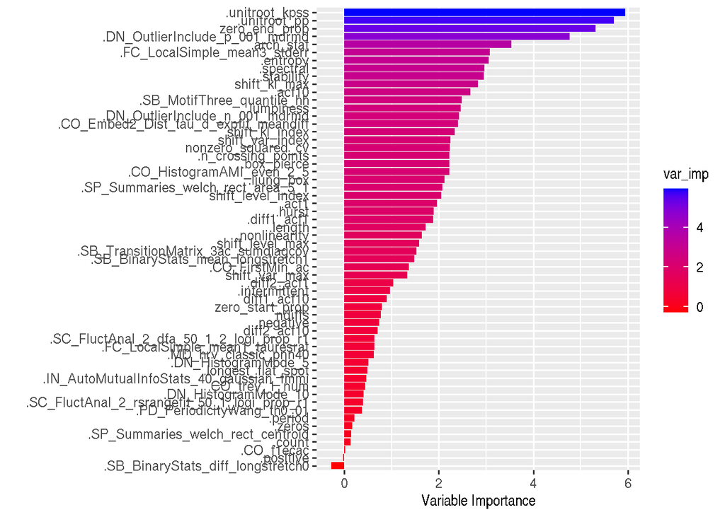

```r
variable_importances <- soothsayer_model_importance[["variable.importance"]]
# rescale so they sum to 100
variable_importances <- (variable_importances/sum(variable_importances)) * 100
df <- data.frame( var_imp = variable_importances, var = names(variable_importances) )

ggplot2::ggplot(df, ggplot2::aes( x = reorder(var,var_imp),
                                  y = var_imp,
                                  fill = var_imp )
                ) +
      ggplot2::geom_bar(stat="identity", position="dodge") +
      ggplot2::coord_flip()+
      ggplot2::ylab("Variable Importance")+
      ggplot2::xlab("")+
      ggplot2::scale_fill_gradient(low="red", high="blue")
```

Pretty, but not super readable - what about top 20?

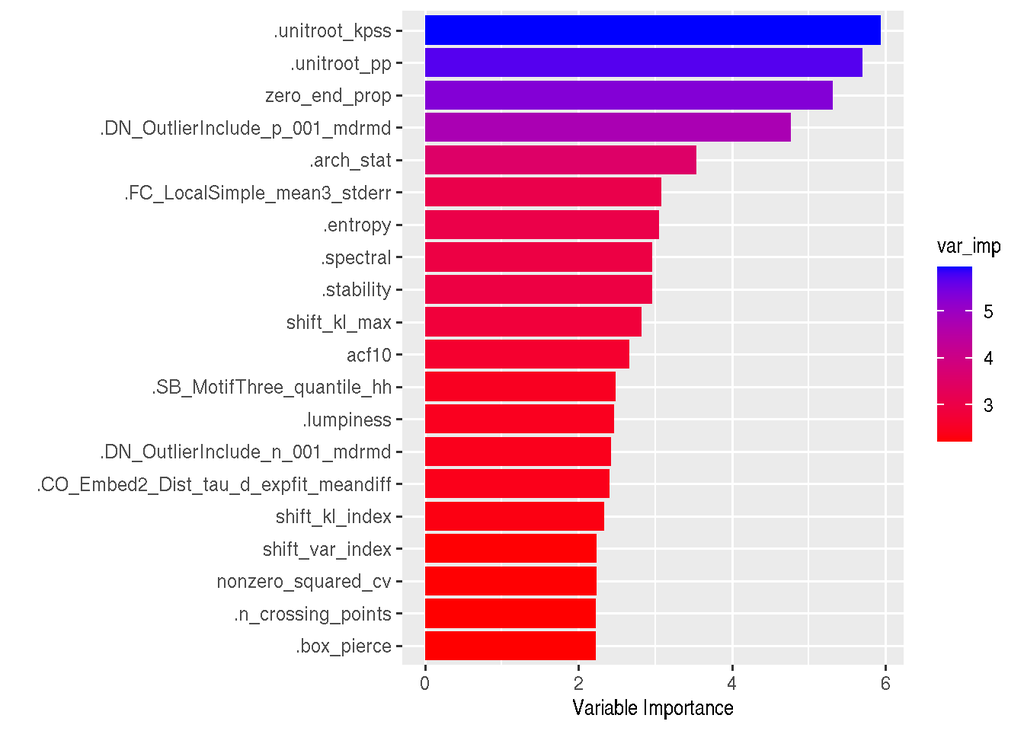

```r
df %>%
  dplyr::arrange(dplyr::desc(var_imp)) %>%
  .[1:20,] %>%
  ggplot2::ggplot( ggplot2::aes( x = reorder(var,var_imp),
                                 y = var_imp,
                                 fill = var_imp )
                 ) +
      ggplot2::geom_bar(stat="identity", position="dodge") +
      ggplot2::coord_flip()+
      ggplot2::ylab("Variable Importance")+
      ggplot2::xlab("")+
      ggplot2::scale_fill_gradient(low="red", high="blue")
```

Interesting. TODO: Elaborate.

```r
preds <- predict(soothsayer_model, soothsayer_test %>%
  dplyr::select(-c(".model", "key")) %>%
  as.matrix(), type = "response")

selected_models <- preds[["predictions"]] %>%
  as.data.frame() %>% dplyr::rowwise() %>%
  dplyr::mutate( best = which.max(dplyr::across())) %>%
  dplyr::ungroup() %>%
  dplyr::mutate( selected_model = colnames(preds[["predictions"]])[best] ) %>%
  dplyr::select( selected_model ) %>%
  dplyr::bind_cols( soothsayer_test ) %>%
  dplyr::select( c("selected_model", "key") )

matches <- accuracies %>%
  dplyr::right_join( selected_models, by = "key" )
```

Are we better than just fitting any individual model to all series?

```r
check_against_model <- function( acc_data, model, metric = "RMSE" ) {

  model_acc <- acc_data %>%
    dplyr::filter( .model == model  ) %>%
    dplyr::select( tidyselect::all_of(c("key", metric)))

  selected_acc <- acc_data %>%
    dplyr::filter( .model == selected_model ) %>%
    dplyr::select(  tidyselect::all_of(c("key", metric)) )

  colnames(selected_acc)[ colnames(selected_acc) == metric ] <- paste0("selected_",metric)

  dplyr::full_join(model_acc, selected_acc, key = "key")
}

performance_vs_single_model <- purrr::map( c("ar", "arima", "croston", "ets", "nnetar", "theta"),
            function( model_name ){
              check_against_model(matches, model_name) %>%
                dplyr::mutate( ratio = RMSE/selected_RMSE) %>%
                # deliberately remove high ratios
                dplyr::filter( ratio < quantile(ratio, probs = 0.99, na.rm = TRUE) &
                               ratio < 10) %>%
                dplyr::summarise( mean_ratio = mean(ratio, na.rm = TRUE)) %>%
                dplyr::mutate( model_name = model_name )
            }) %>%
  dplyr::bind_rows()
```

We get the performance against each individual model: The ratio is the RMSE of a given model, vs our model (averaged). Thus, numbers > 1 are good, numbers < 1 are bad, etc.

```r
knitr::kable(performance_vs_single_model)
```

| mean_ratio | model_name |
| --- | --- |
| 1.338511 | ar |
| 1.168373 | arima |
| 1.630398 | croston |
| 1.191464 | ets |
| 1.375116 | nnetar |
| 1.271967 | theta |

So we pretty much beat any single model individually (cool!). Maybe that changes with different metrics, or we can do even better.

How often do we do better, and how often do we do worse, though?

```r
better_or_worse_than_single_model <- purrr::map( c("ar", "arima", "croston", "ets", "nnetar", "theta"),
            function( model_name ){
              check_against_model(matches, model_name) %>%
                dplyr::mutate( ratio = RMSE/selected_RMSE) %>%
                dplyr::filter( !is.na(ratio) ) %>%
                dplyr::summarise( worse = sum(ratio < 1)/length(ratio),
                                  better_or_equal = sum(ratio >= 1)/length(ratio)) %>%
                dplyr::mutate( model_name = model_name )
            }) %>%
  dplyr::bind_rows()
knitr::kable(better_or_worse_than_single_model, digits = 2)
```

| worse | better_or_equal | model_name |
| --- | --- | --- |
| 0.23 | 0.77 | ar |
| 0.33 | 0.67 | arima |
| 0.29 | 0.71 | croston |
| 0.37 | 0.63 | ets |
| 0.27 | 0.73 | nnetar |
| 0.29 | 0.71 | theta |

```r
check_against_best_model <- function( acc_data, metric = "RMSE" ) {

  model_acc <- acc_data %>%
    dplyr::select( tidyselect::all_of(c(metric,"key"))) %>%
    dplyr::group_by(key) %>%
    dplyr::mutate(ranking = dplyr::across(where(is.numeric), dplyr::min_rank)) %>%
    dplyr::filter(ranking == 1) %>%
    dplyr::ungroup() %>%
    dplyr::select( tidyselect::all_of(c(metric, "key")))

  selected_acc <- acc_data %>%
    dplyr::filter( .model == selected_model ) %>%
    dplyr::select(  tidyselect::all_of(c("key", metric)) )

  colnames(selected_acc)[ colnames(selected_acc) == metric ] <- paste0("selected_",metric)

  dplyr::full_join(model_acc, selected_acc, key = "key")
}

performance_vs_best_model <-
              check_against_best_model(matches) %>%
                dplyr::mutate( ratio = RMSE/selected_RMSE)
knitr::kable(dplyr::summarise( performance_vs_best_model, mean_ratio = mean(ratio, na.rm = TRUE)) )
```

| mean_ratio |
| --- |
| 0.8654468 |

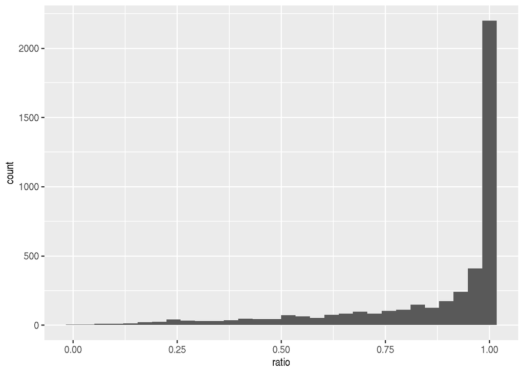

```r
performance_vs_best_model %>%
  ggplot2::ggplot( ggplot2::aes(x = ratio)) +
  ggplot2::geom_histogram()
```

That looks like we pick the best model (or close to it) quite often - lets check:

```r
performance_vs_best_model %>%
  dplyr::summarise( picked_almost_best = sum(ratio > 0.95, na.rm = TRUE)/length(na.omit(ratio)),
                    picked_best = sum(ratio == 1, na.rm = TRUE)/length(na.omit(ratio))) %>%
  knitr::kable()
```

| picked_almost_best | picked_best |
| --- | --- |
| 0.5873951 | 0.3672637 |

How often do we fail (i.e. how often do we pick a model with a RMSE more than 20% worse than the best one) ?

```r
bad <- performance_vs_best_model %>%
  dplyr::summarise( picked_bad = sum(ratio < 0.8, na.rm = TRUE)/length(na.omit(ratio)))

  knitr::kable(bad)
```

| picked_bad |
| --- |
| 0.2457493 |

About 24.5749263% of the time - unfortunate. Just how bad are these picks, and where do they tend to cluster?

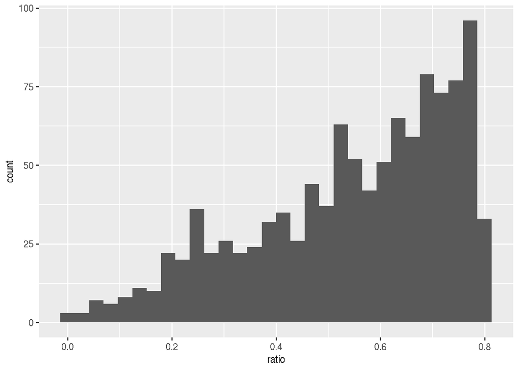

```r
performance_vs_best_model %>%
  dplyr::filter( ratio < 0.8 ) %>%
  ggplot2::ggplot( ggplot2::aes(x = ratio)) +
  ggplot2::geom_histogram()
```

TODO: We need to look a bit deeper into the cases where we fail.

# TODO:

# Podium counts: (3 best methods get re-sampled probabilistically)

```r
podium_counts <- accuracy_ranks %>%
  dplyr::group_by(key) %>%
  dplyr::arrange( avg_rank ) %>%
  dplyr::slice_head(n = 3) %>%
  dplyr::select(.model, key) %>%
  dplyr::ungroup()
```